# Bayesian multi-level model for data with structured dispersion

This post provides code to model variance components in a multi-level setting. This is useful when variances are heteroskedastic and, we suspect, heteroskedasticity is driven by some observed variable(s).

#### Steps:

1. Load the data. For this demonstration I will simulate data in which 600 individual ($i$) are nested into 200 groups ($j$). $Y$ is the outcome variable and I allow for random intercepts at the group level plus structured dispersion at both group-level and individual-level. In this particular case the variance components are functions of the same variable $z$, but this predictor has opposite effects on each of them.

More formally, the DGP can be described as: $Y = \mathbf{1}_{k} \otimes \mathbf{1}_{n}\mu + \mathbf{I}_{k} \otimes \mathbf{1}_{n} \mathbf{a} + \mathbf{I}_{k} \otimes \mathbf{I}_{n} \mathbf{e}$, where $\mathbf{a}$ and $\mathbf{e}$ are random effects, such that $\mathbf{a} \sim N(\mathbf{0}, \mathbf{\sigma_{a}})$ and $\mathbf{e} \sim N(\mathbf{0}, \mathbf{\sigma_{e}})$. Moreover, both variances are functions of $z$: $\mathbf{\sigma_{a}}=f(\mathbf{z})$ and $\mathbf{\sigma_{e}}=g(\mathbf{z})$.

```r
n=3   # Number of individuals by group
k=200 # Number of  groups
# Design matrices for multi-levels
One.k=matrix(rep(1,k))
One.n=matrix(rep(1,n))
I.k=diag(k)
I.n=diag(n)
mu=0
# variance predictor
z = runif(k,1,5)               # indep variable in variance function at group level
Z = (I.k%x%One.n)%*%z          # indep variable in variance function at individual level
# An arbitrary function for variance at the group level
THETA_a0 =  -5
THETA_a1  = 1.9
var.a = exp(THETA_a0 + THETA_a1*z + rnorm(k))
sd.a  = sqrt(var.a)
# An arbitrary function for variance at individual level (residual variance)
THETA_e0 =  5
THETA_e1  = -2.7
var.e = exp(THETA_e0 + THETA_e1*Z + rnorm(k*n))
sd.e  = sqrt(var.e)
# Random intercepts
a=rnorm(k,0,sd.a)
# Random error
e=rnorm(k*n,0,sd.e)
# Creates Y = mu + random intercept + random error
Y = (One.k%x%One.n)*mu + (I.k%x%One.n)%*%a + (I.k%x%I.n)%*%e
# Generate indicators. To be used later.
group=matrix(rep(1:k))  # vector with group indicator for each group
Group=(I.k%x%One.n)%*%group # vector with Group indicator for each individual
```

A simple scatterplot of $Y$ and $z$ should reveal variance structure.

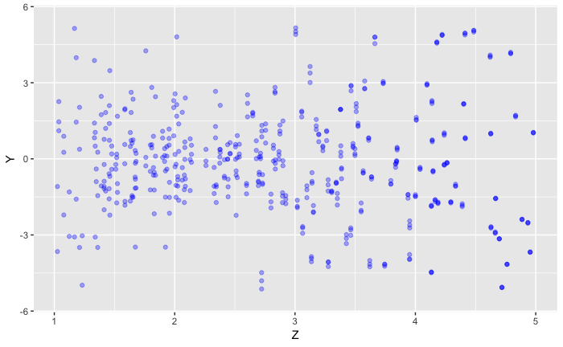

2. Load `rstan` to perform Bayesian estimation via Halmiltonian Monte Carlo. Put the data into a list.

```r
library("rstan")
Data_l1 <- data.frame(Y,Group,Z) # data individual-level
Data_l2 <- data.frame(group,z)   # data group-level
data    <- list(N=n*k,J=k,y=Data_l1$Y,G=Data_l1$Group,Z=Data_l1$Z, g=Data_l2$group,z=Data_l2$z)
```

3. Write the model in `stan`.

```r
structured_dispersion <- '
data {
  int<lower=0> J;                   // number of groups
  int<lower=0> N;                   // number of individuals
  int<lower=1, upper=J>  G[N];      // map individuals to groups
  vector[N] y;                      // outcome variable
  vector[J] z;                      // group level dispersion predictor
  vector[N] Z;                      // individual level dispersion predictor
}
parameters {
  vector[J] a;                           // Random Intercept

  real theta_a0;                         // Intercept model for variance of random intercept
  real theta_e0;                         // Intercept model for variance of residual error

  real theta_a1;                         // Slope model for variance of random intercept
  real theta_e1;                         // Slope model for variance of residual error
  vector<lower=0>[J] sigma2_a;           // heterogeneous var for random intercept
  vector<lower=0>[N] sigma2_e;           // heterogeneous var residual error
}
transformed parameters {

  vector[N] y_mu;                        // Random effects
  vector[J] logsigma2_a_mu;              // mean of log-variance for random intercept
  vector[J] sigma2_a_mu;                 // mean of variance for random intercept
  vector[J] sigma_a;                     // var for random intercept
  vector[N] logsigma2_e_mu;              // mean of log-variance residual error
  vector[N] sigma2_e_mu;                 // mean of var residual error
  vector[N] sigma_e;                     // var residual error
  for (i in 1:J) {
                                         // Assigns a different sd to each random intercept
    logsigma2_a_mu[i] = theta_a0 + theta_a1*z[i];
    sigma2_a_mu[i]    = exp(logsigma2_a_mu[i]);
    sigma_a[i]        = sqrt(sigma2_a_mu[i]);
  }
  for (i in 1:N) {
                                          // Assigns a different sd to each residual error
    logsigma2_e_mu[i] = theta_e0 + theta_e1*Z[i];
    sigma2_e_mu[i]    = exp(logsigma2_e_mu[i]);
    sigma_e[i]        = sqrt(sigma2_e_mu[i]);
                                          // Assigns a different predicted mean to ech individual depending of group of belonging
    y_mu[i] = a[G[i]];
  }
}
model {
  // Priors
  theta_a0    ~ cauchy(0,2.5);
  theta_e0    ~ cauchy(0,2.5);
  theta_a1    ~ cauchy(0,2.5);
  theta_e1    ~ cauchy(0,2.5);
  // Variances
  sigma2_a ~ lognormal(sigma2_a_mu,0.25);
  sigma2_e ~ lognormal(sigma2_e_mu,0.25);
  // Random intercept
  a ~ normal(0, sigma_a);
  // Outcome variable
  y ~ normal(y_mu, sigma_e);
}
'
```

4. Fit the model and compare the estimates to the parameters used in the DGP.

```r
mymodel <- stan(model_code=structured_dispersion, model_name="structured_dispersion",
iter=2000, pars=c("theta_e0", "theta_e1","theta_a0", "theta_a1"), data=data, chains=3)
```

```r
print(mymodel)
```

```
Inference for Stan model: structured_dispersion.
3 chains, each with iter=2000; warmup=1000; thin=1;
post-warmup draws per chain=1000, total post-warmup draws=3000.

           mean se_mean    sd    2.5%    25%    50%    75%  97.5% n_eff Rhat
theta_e0   5.63    0.06  0.19    5.31   5.46   5.63   5.73   6.04    10 1.17
theta_e1  -2.79    0.02  0.06   -2.91  -2.82  -2.79  -2.75  -2.68    12 1.13
theta_a0  -3.87    0.20  0.46   -4.69  -4.24  -3.83  -3.53  -3.07     5 1.80
theta_a1   1.73    0.06  0.12    1.53   1.64   1.73   1.81   1.96     4 1.96
lp__     -63.59    3.02 23.12 -110.10 -78.88 -63.47 -47.50 -20.06    59 1.04

Samples were drawn using NUTS(diag_e) at Mon Dec  3 17:15:39 2018.
For each parameter, n_eff is a crude measure of effective sample size,
and Rhat is the potential scale reduction factor on split chains (at
convergence, Rhat=1).
```

5. Uset he function`launch_shinystan` from package `rstanarm` to get visual and numerical summaries of model parameters and convergence diagnostics.